# ISE201_Final_Project

Artem Abdikov

2024-12-07

## Dataset introduction

The dataset selected is City of San Jose fire incidents from the year of 2023. The dataset contains records of all incidents involving the Fire Department of San Jose. The primary reasons for choosing this dataset was it being a real life dataset in a sea of synthetic educational datasets as well as its proximity. Visiting San Jose frequently increases its relevance. The exploration of this dataset is relevant for me and should be relevant for anyone because anyone might require firefighters’ help at some point and even one’s life might depend on them. It is beneficial to have an idea how they operate and if you can expect them to show up fast. Primary focus of the analysis is dedicated to time in between all the phases (from the call to clear).

The data is very rich, potential questions could be: How fast is a response time (is it fast enough or is it dangerously slow)? How many incidents a day are happening and what time is the most busy (is there a time of day where more manpower needed)? How many incidents each station/battalion get (are they overworked, do they need more people)? What are the most incident-rich streets (more departments needed there)? What is the trend (more incidents or less)? All these questions should be analyzed since a lot of lives depend on proper work of Fire Department.

The source of the data is https://data.sanjoseca.gov/ , the official data portal of San Jose. The data was compiled by government employees. The study was observational since these are just recordings of events that happened. Each entry (row) is a fire department related incident. The data has: 2 identification columns, denoting each unique incident (2 is redundant, 1 will be removed). Several timestamp columns at different stages of an incident, the time of call, dispatch time, time the unit left the station, time the unit is on scene and time the incident was cleared. On-scene Unit column suggests the main unit assigned to the incident and the Unit_count column shows if any units that joined the main one and if so how many total were engaged. Some other categorical data is priority, indcident type and final incident category, describing the incident. Street name denotes the street the incident took place. Station columns indicates the station assigned to the incident and battalion denotes the battalion (crew) sent on the incident.

## Dataset showcase and EDA

The data looks as follows:

```r
library(tidyverse)
rawdata <- read.csv("sanjosefireincidents_2023.csv")
head(rawdata)
```

```
##   X_id Incident_No  Date_Time_Of_Event     Dispatched_Time Unit_On_The_Way_Time
## 1    1  F230019001 2023-01-01 00:04:00 2023-01-01 00:05:00  2023-01-01 00:07:00
## 2    2  F230019002 2023-01-01 00:08:00 2023-01-01 00:08:00  2023-01-01 00:10:00
## 3    3  F230019003 2023-01-01 00:08:00 2023-01-01 00:09:00  2023-01-01 00:11:00
## 4    4  F230019004 2023-01-01 00:09:00 2023-01-01 00:10:00  2023-01-01 00:12:00
## 5    5  F230019005 2023-01-01 00:13:00
## 6    6  F230019006 2023-01-01 00:13:00 2023-01-01 00:14:00  2023-01-01 00:16:00
##   Unit_On_Scene_TimeStamp On_Scene_Unit   Cleared_TimeStamp Unit_Count
## 1     2023-01-01 00:12:00           E18 2023-01-01 00:25:00          1
## 2     2023-01-01 00:13:00           E16 2023-01-01 00:39:00          1
## 3     2023-01-01 00:17:00           T16 2023-01-01 00:30:00          1
## 4     2023-01-01 00:15:00           E22 2023-01-01 00:37:00          1
## 5                                                                    0
## 6     2023-01-01 00:20:00            E1 2023-01-01 00:33:00          1
##     Priority Final_Incident_Type Final_Incident_Category  Street_Name Station
## 1 Priority 1             MEDICAL            Medical Only      VERA LN      18
## 2 Priority 1             MEDICAL            Medical Only                   16
## 3 Priority 2             MEDICAL            Medical Only      KARL ST      16
## 4 Priority 1             MEDICAL            Medical Only     MENLO DR      22
## 5 Priority 1             MEDICAL           Uncategorized
## 6 Priority 2             MEDICAL            Medical Only W ST JOHN ST       1
##   Battalion
## 1     BAT13
## 2      BAT2
## 3      BAT2
## 4     BAT13
## 5      BAT1
## 6      BAT1
```

```r
summary(rawdata)
```

```
##       X_id        Incident_No        Date_Time_Of_Event Dispatched_Time
##  Min.   :     1   Length:114357      Length:114357      Length:114357
##  1st Qu.: 28590   Class :character   Class :character   Class :character
##  Median : 57179   Mode  :character   Mode  :character   Mode  :character
##  Mean   : 57179
##  3rd Qu.: 85768
##  Max.   :114357
##  Unit_On_The_Way_Time Unit_On_Scene_TimeStamp On_Scene_Unit
##  Length:114357        Length:114357           Length:114357
##  Class :character     Class :character        Class :character
##  Mode  :character     Mode  :character        Mode  :character
##
##
##
##  Cleared_TimeStamp    Unit_Count       Priority         Final_Incident_Type
##  Length:114357      Min.   : 0.000   Length:114357      Length:114357
##  Class :character   1st Qu.: 1.000   Class :character   Class :character
##  Mode  :character   Median : 1.000   Mode  :character   Mode  :character
##                     Mean   : 1.383
##                     3rd Qu.: 2.000
##                     Max.   :32.000
##  Final_Incident_Category Street_Name          Station
##  Length:114357           Length:114357      Length:114357
##  Class :character        Class :character   Class :character
##  Mode  :character        Mode  :character   Mode  :character
##
##
##
##   Battalion
##  Length:114357
##  Class :character
##  Mode  :character
##
##
##
```

As can be seen, the data is fairly raw and requires both general cleanup as well as some preparations for my particular study (transformation of dates between the phases into time elapsed in between them).

Starting with data type assignment and reasessment of summary function.

```r
rawdata$Incident_No <- as.factor(rawdata$Incident_No)
rawdata$Date_Time_Of_Event <- strptime(rawdata$Date_Time_Of_Event,format="%Y-%m-%d  %H:%M")
rawdata$Dispatched_Time <- strptime(rawdata$Dispatched_Time,format="%Y-%m-%d  %H:%M")
rawdata$Unit_On_The_Way_Time <- strptime(rawdata$Unit_On_The_Way_Time,format="%Y-%m-%d  %H:%M")
rawdata$Unit_On_Scene_TimeStamp <- strptime(rawdata$Unit_On_Scene_TimeStamp,format="%Y-%m-%d  %H:%M")
rawdata$On_Scene_Unit <- as.factor(rawdata$On_Scene_Unit)
rawdata$Cleared_TimeStamp <- strptime(rawdata$Cleared_TimeStamp,format="%Y-%m-%d  %H:%M")
rawdata$Priority <- as.factor(rawdata$Priority)
rawdata$Final_Incident_Type <- as.factor(rawdata$Final_Incident_Type)
rawdata$Final_Incident_Category <- as.factor(rawdata$Final_Incident_Category)
rawdata$Street_Name <- as.factor(rawdata$Street_Name)
rawdata$Station <- as.factor(rawdata$Station)
rawdata$Battalion <- as.factor(rawdata$Battalion)

summary(rawdata)
```

```
##       X_id            Incident_No     Date_Time_Of_Event
##  Min.   :     1   F230019001:     1   Min.   :2023-01-01 00:04:00.00
##  1st Qu.: 28590   F230019002:     1   1st Qu.:2023-04-02 05:05:00.00
##  Median : 57179   F230019003:     1   Median :2023-07-03 22:22:00.00
##  Mean   : 57179   F230019004:     1   Mean   :2023-07-03 00:59:56.26
##  3rd Qu.: 85768   F230019005:     1   3rd Qu.:2023-10-02 17:48:00.00
##  Max.   :114357   F230019006:     1   Max.   :2023-12-31 23:57:00.00
##                   (Other)   :114351
##  Dispatched_Time                  Unit_On_The_Way_Time
##  Min.   :2023-01-01 00:05:00.00   Min.   :2023-01-01 00:07:00.00
##  1st Qu.:2023-04-02 15:39:30.00   1st Qu.:2023-04-02 17:30:45.00
##  Median :2023-07-04 01:35:30.00   Median :2023-07-04 05:02:30.00
##  Mean   :2023-07-03 05:58:47.17   Mean   :2023-07-03 07:09:14.75
##  3rd Qu.:2023-10-03 00:22:15.00   3rd Qu.:2023-10-03 02:06:30.00
##  Max.   :2023-12-31 23:57:00.00   Max.   :2023-12-31 23:58:00.00
##  NA's   :10915                    NA's   :11653
##  Unit_On_Scene_TimeStamp          On_Scene_Unit
##  Min.   :2023-01-01 00:12:00.00          :12506
##  1st Qu.:2023-04-03 01:23:30.00   E1     : 4256
##  Median :2023-07-04 08:20:00.00   E4     : 4211
##  Mean   :2023-07-03 09:53:49.96   E2     : 4026
##  3rd Qu.:2023-10-03 04:19:00.00   E8     : 3920
##  Max.   :2024-01-01 00:03:00.00   E26    : 3857
##  NA's   :12506                    (Other):81581
##  Cleared_TimeStamp                  Unit_Count           Priority
##  Min.   :2023-01-01 00:25:00.00   Min.   : 0.000   Priority 1:91646
##  1st Qu.:2023-04-02 13:44:00.00   1st Qu.: 1.000   Priority 2:22711
##  Median :2023-07-04 02:19:00.00   Median : 1.000
##  Mean   :2023-07-03 05:50:50.71   Mean   : 1.383
##  3rd Qu.:2023-10-02 23:15:30.00   3rd Qu.: 2.000
##  Max.   :2024-01-01 02:18:00.00   Max.   :32.000
##  NA's   :5558
##  Final_Incident_Type                                    Final_Incident_Category
##  FIRE_OTHER:23866    Medical Only                                   :68054
##  MEDICAL   :90491    Uncategorized                                  :16872
##                      Good Intent Or Service                         :10992
##                      Rescue, HazMat, USAR & Non-Fire Hazards        : 6326
##                      No Incident, Wrong Location, Cancelled En Route: 6123
##                      Other Fires                                    : 3112
##                      (Other)                                        : 2878
##           Street_Name       Station        Battalion
##                 :18645   26     : 6569   BAT1   :28922
##  MONTEREY RD    : 1681   2      : 6123   BAT10  :25078
##  N 1ST ST       : 1178   1      : 5756   BAT2   :23779
##  SENTER RD      :  989   3      : 5494   BAT13  :21035
##  S BASCOM AV    :  974   4      : 5290   BAT5   :15340
##  BLOSSOM HILL RD:  954   8      : 4557   MISC   :  147
##  (Other)        :89936   (Other):80568   (Other):   56
```

Removing the useless Incident_No column. Any row is identifiable by just id.

```r
data <- subset(rawdata, select=-c(Incident_No))
```

Performing aforementioned transformation of dates into just time elapsed between each phase.

```r
data$e_to_d_min <- as.numeric(data$Dispatched_Time - data$Date_Time_Of_Event)/60
data$d_to_otw_min <- as.numeric(data$Unit_On_The_Way_Time - data$Dispatched_Time)/60
data$otw_to_os_min <- as.numeric(data$Unit_On_Scene_TimeStamp - data$Unit_On_The_Way_Time)/60
data$os_to_c_min <- as.numeric(data$Cleared_TimeStamp-data$Unit_On_Scene_TimeStamp)/60
```

Assessing NA situation in our data.

```r
na_count <-sapply(data, function(y) sum(length(which(is.na(y)))))
na_count
```

```
##                    X_id      Date_Time_Of_Event         Dispatched_Time
##                       0                       0                   10915
##    Unit_On_The_Way_Time Unit_On_Scene_TimeStamp           On_Scene_Unit
##                   11653                   12506                       0
##       Cleared_TimeStamp              Unit_Count                Priority
##                    5558                       0                       0
##     Final_Incident_Type Final_Incident_Category             Street_Name
##                       0                       0                       0
##                 Station               Battalion              e_to_d_min
##                       0                       0                   10915
##            d_to_otw_min           otw_to_os_min             os_to_c_min
##                   11718                   13241                   12509
```

The only missing data is certain timestamps and there are not so many of them, we can sacrifice them since we still have >10000 entries after.

Removing NAs.

```r
nonadata <- na.omit(data)
```

Another summary to check where we’re at now and what to do next.

```r
summary(nonadata)
```

```
##       X_id        Date_Time_Of_Event
##  Min.   :     1   Min.   :2023-01-01 00:04:00.00
##  1st Qu.: 28831   1st Qu.:2023-04-03 04:24:00.00
##  Median : 57326   Median :2023-07-04 11:01:00.00
##  Mean   : 57313   Mean   :2023-07-03 11:18:03.92
##  3rd Qu.: 85912   3rd Qu.:2023-10-03 05:54:30.00
##  Max.   :114356   Max.   :2023-12-31 23:55:00.00
##
##  Dispatched_Time                  Unit_On_The_Way_Time
##  Min.   :2023-01-01 00:05:00.00   Min.   :2023-01-01 00:07:00.00
##  1st Qu.:2023-04-03 04:25:00.00   1st Qu.:2023-04-03 04:27:30.00
##  Median :2023-07-04 11:01:00.00   Median :2023-07-04 11:01:00.00
##  Mean   :2023-07-03 11:19:39.42   Mean   :2023-07-03 11:20:58.10
##  3rd Qu.:2023-10-03 05:55:00.00   3rd Qu.:2023-10-03 05:57:00.00
##  Max.   :2023-12-31 23:56:00.00   Max.   :2023-12-31 23:58:00.00
##
##  Unit_On_Scene_TimeStamp          On_Scene_Unit
##  Min.   :2023-01-01 00:12:00.00   E1     : 4211
##  1st Qu.:2023-04-03 04:31:00.00   E4     : 4189
##  Median :2023-07-04 11:04:00.00   E2     : 3997
##  Mean   :2023-07-03 11:25:57.97   E8     : 3890
##  3rd Qu.:2023-10-03 06:01:30.00   E26    : 3823
##  Max.   :2024-01-01 00:03:00.00   E16    : 3705
##                                   (Other):77236
##  Cleared_TimeStamp                  Unit_Count           Priority
##  Min.   :2023-01-01 00:25:00.00   Min.   : 1.000   Priority 1:80566
##  1st Qu.:2023-04-03 04:45:00.00   1st Qu.: 1.000   Priority 2:20485
##  Median :2023-07-04 11:26:00.00   Median : 1.000
##  Mean   :2023-07-03 11:43:12.69   Mean   : 1.453
##  3rd Qu.:2023-10-03 06:22:00.00   3rd Qu.: 2.000
##  Max.   :2024-01-01 02:18:00.00   Max.   :32.000
##
##  Final_Incident_Type                                    Final_Incident_Category
##  FIRE_OTHER:17973    Medical Only                                   :66571
##  MEDICAL   :83078    Good Intent Or Service                         :10101
##                      Uncategorized                                  : 9291
##                      Rescue, HazMat, USAR & Non-Fire Hazards        : 6119
##                      No Incident, Wrong Location, Cancelled En Route: 3228
##                      Other Fires                                    : 2986
##                      (Other)                                        : 2755
##            Street_Name       Station        Battalion       e_to_d_min
##                  :15338   26     : 6045   BAT1   :25583   Min.   :  0.000
##  MONTEREY RD     : 1565   2      : 5447   BAT2   :21813   1st Qu.:  1.000
##  N 1ST ST        : 1031   1      : 5093   BAT10  :21348   Median :  1.000
##  SENTER RD       :  915   3      : 4942   BAT13  :18975   Mean   :  1.592
##  BLOSSOM HILL RD :  859   4      : 4758   BAT5   :13326   3rd Qu.:  2.000
##  E SANTA CLARA ST:  742   16     : 4138   ADMIN  :    5   Max.   :543.000
##  (Other)         :80601   (Other):70628   (Other):    1
##   d_to_otw_min     otw_to_os_min       os_to_c_min
##  Min.   :-78.000   Min.   :-366.000   Min.   :-118.00
##  1st Qu.:  1.000   1st Qu.:   4.000   1st Qu.:   8.00
##  Median :  1.000   Median :   5.000   Median :  13.00
##  Mean   :  1.311   Mean   :   4.998   Mean   :  17.25
##  3rd Qu.:  2.000   3rd Qu.:   6.000   3rd Qu.:  21.00
##  Max.   : 91.000   Max.   : 614.000   Max.   :6352.00
##
```

However, if we look at the newly introduced time elapsed columns we can spot an anomaly. Negative time. I specifically kept the logic of my arithmetical operations to have them as positive numbers only. Let us take a look how these negative numbers occurred.

```r
head(nonadata[nonadata[16] < 0, c("Dispatched_Time", "Unit_On_The_Way_Time")])
```

```
##           Dispatched_Time Unit_On_The_Way_Time
## 4372  2023-01-14 11:04:00  2023-01-14 10:37:00
## 4380  2023-01-14 11:04:00  2023-01-14 10:37:00
## 38907 2023-05-06 09:25:00  2023-05-06 09:23:00
## 49928 2023-06-10 05:23:00  2023-06-10 05:05:00
## 49934 2023-06-10 05:23:00  2023-06-10 05:05:00
## 54735 2023-06-26 08:11:00  2023-06-26 07:47:00
```

```r
head(nonadata[nonadata[17] < 0, c("Unit_On_The_Way_Time", "Unit_On_Scene_TimeStamp")])
```

```
##      Unit_On_The_Way_Time Unit_On_Scene_TimeStamp
## 208   2023-01-01 13:37:00     2023-01-01 13:22:00
## 1082  2023-01-04 12:22:00     2023-01-04 11:55:00
## 1246  2023-01-04 21:57:00     2023-01-04 21:37:00
## 1452  2023-01-05 15:05:00     2023-01-05 14:08:00
## 1922  2023-01-07 01:04:00     2023-01-07 00:26:00
## 1946  2023-01-07 02:42:00     2023-01-07 02:22:00
```

```r
head(nonadata[nonadata[18] < 0, c("Unit_On_The_Way_Time", "Cleared_TimeStamp")])
```

```
##       Unit_On_The_Way_Time   Cleared_TimeStamp
## 96379  2023-11-05 01:34:00 2023-11-05 01:04:00
## 96380  2023-11-05 01:53:00 2023-11-05 01:06:00
## 96381  2023-11-05 01:57:00 2023-11-05 01:01:00
```

From this output we can see that the entries are probably erroneous or have some meaning unknown to us. Since the amount of such entries is minimal, we remove it as potentially bad data.

```r
nonadata <- nonadata[nonadata$e_to_d_min >= 0, ]
nonadata <- nonadata[nonadata$d_to_otw_min >= 0, ]
nonadata <- nonadata[nonadata$otw_to_os_min >= 0, ]
nonadata <- nonadata[nonadata$os_to_c_min >= 0, ]

summary(nonadata)
```

```
##       X_id        Date_Time_Of_Event
##  Min.   :     1   Min.   :2023-01-01 00:04:00.00
##  1st Qu.: 28815   1st Qu.:2023-04-03 02:24:00.00
##  Median : 57302   Median :2023-07-04 09:04:00.00
##  Mean   : 57296   Mean   :2023-07-03 10:02:51.30
##  3rd Qu.: 85888   3rd Qu.:2023-10-03 02:42:00.00
##  Max.   :114356   Max.   :2023-12-31 23:55:00.00
##
##  Dispatched_Time                  Unit_On_The_Way_Time
##  Min.   :2023-01-01 00:05:00.00   Min.   :2023-01-01 00:07:00.00
##  1st Qu.:2023-04-03 02:26:00.00   1st Qu.:2023-04-03 02:28:00.00
##  Median :2023-07-04 09:04:00.00   Median :2023-07-04 09:06:00.00
##  Mean   :2023-07-03 10:04:16.67   Mean   :2023-07-03 10:05:35.53
##  3rd Qu.:2023-10-03 02:44:00.00   3rd Qu.:2023-10-03 02:46:00.00
##  Max.   :2023-12-31 23:56:00.00   Max.   :2023-12-31 23:58:00.00
##
##  Unit_On_Scene_TimeStamp          On_Scene_Unit
##  Min.   :2023-01-01 00:12:00.00   E1     : 4187
##  1st Qu.:2023-04-03 02:32:00.00   E4     : 4175
##  Median :2023-07-04 09:12:00.00   E2     : 3979
##  Mean   :2023-07-03 10:10:45.71   E8     : 3875
##  3rd Qu.:2023-10-03 02:50:00.00   E26    : 3813
##  Max.   :2024-01-01 00:03:00.00   E16    : 3682
##                                   (Other):76966
##  Cleared_TimeStamp                  Unit_Count           Priority
##  Min.   :2023-01-01 00:25:00.00   Min.   : 1.000   Priority 1:80203
##  1st Qu.:2023-04-03 02:43:00.00   1st Qu.: 1.000   Priority 2:20474
##  Median :2023-07-04 09:33:00.00   Median : 1.000
##  Mean   :2023-07-03 10:27:59.31   Mean   : 1.451
##  3rd Qu.:2023-10-03 02:56:00.00   3rd Qu.: 2.000
##  Max.   :2024-01-01 02:18:00.00   Max.   :32.000
##
##  Final_Incident_Type                                    Final_Incident_Category
##  FIRE_OTHER:17937    Medical Only                                   :66374
##  MEDICAL   :82740    Good Intent Or Service                         :10082
##                      Uncategorized                                  : 9255
##                      Rescue, HazMat, USAR & Non-Fire Hazards        : 6049
##                      No Incident, Wrong Location, Cancelled En Route: 3201
##                      Other Fires                                    : 2977
##                      (Other)                                        : 2739
##            Street_Name       Station        Battalion       e_to_d_min
##                  :15232   26     : 6026   BAT1   :25454   Min.   :  0.000
##  MONTEREY RD     : 1562   2      : 5426   BAT2   :21731   1st Qu.:  1.000
##  N 1ST ST        : 1026   1      : 5066   BAT10  :21292   Median :  1.000
##  SENTER RD       :  912   3      : 4898   BAT13  :18910   Mean   :  1.423
##  BLOSSOM HILL RD :  855   4      : 4746   BAT5   :13284   3rd Qu.:  2.000
##  E SANTA CLARA ST:  741   16     : 4116   ADMIN  :    5   Max.   :543.000
##  (Other)         :80349   (Other):70399   (Other):    1
##   d_to_otw_min    otw_to_os_min     os_to_c_min
##  Min.   : 0.000   Min.   :  0.00   Min.   :   0.00
##  1st Qu.: 1.000   1st Qu.:  4.00   1st Qu.:   8.00
##  Median : 1.000   Median :  5.00   Median :  13.00
##  Mean   : 1.314   Mean   :  5.17   Mean   :  17.23
##  3rd Qu.: 2.000   3rd Qu.:  6.00   3rd Qu.:  21.00
##  Max.   :91.000   Max.   :614.00   Max.   :6352.00
##
```

Now our summary statistics make sense. We can see that on average from call to dispatch it take 1.423 minutes, from dispatch to the crew being on the way it is 1.314 minutes on average. It takes 5.17 minutes on average to get to the incident and 17.23 minutes to deal with the incident.

## Grouping and visualization

My first point of interest would be seeing how many cases each unit covered through the year for general information as I get started.

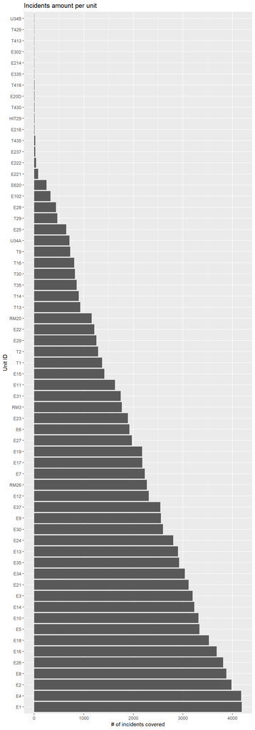

```r
nonadata %>%  group_by(On_Scene_Unit) %>% summarise(n = n()) %>% ggplot() + geom_bar(mapping = aes(x = reorder(On_Scene_Unit, -n), y = n), stat="identity") + coord_flip() + labs(y="# of incidents covered", x="Unit ID", title="Incidents amount per unit")
```

From this we can see that there are two most called units, E1 and E4, while there are a handful of units that are barely ever assigned. No conclusions can be drawn since we know that there can be several units on the scene with only 1 being main, so these couple of units might be mostly supporting ones. There are also specializations among units, so these could be the most niche units only needed in very particular situations.

Another point of interest is average time each unit requires on each stage. Starting with time from event to dispatch.

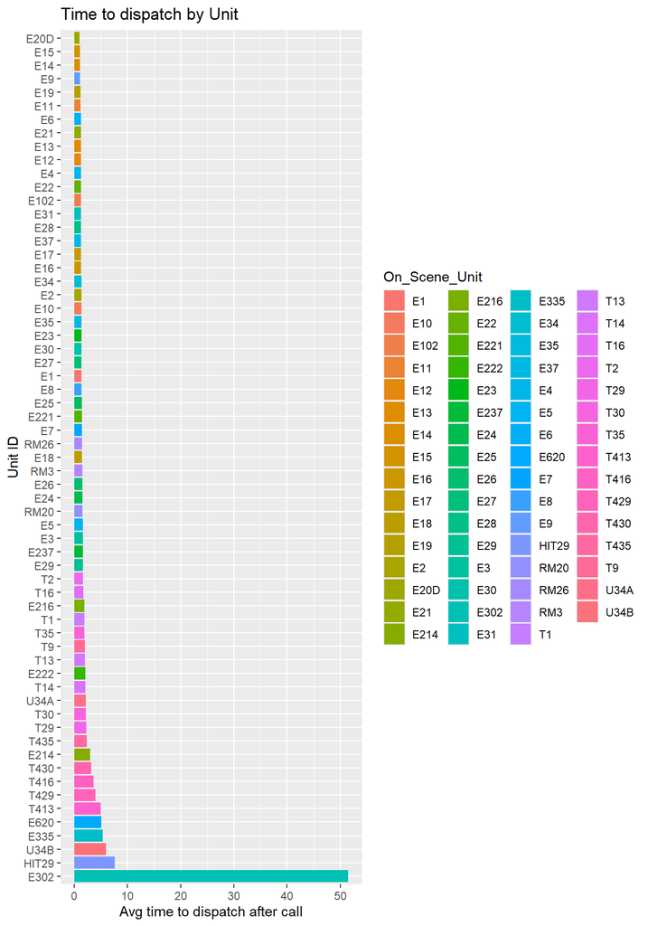

```r
nonadata %>% group_by(On_Scene_Unit) %>% summarise(avg = mean(e_to_d_min)) %>% ggplot(mapping = aes(x = reorder(On_Scene_Unit, -avg), y = avg, fill=On_Scene_Unit)) + geom_bar(stat = "identity") + coord_flip() + labs(y="Avg time to dispatch after call", x="Unit ID", title="Time to dispatch by Unit")
```

From this plot we can see one anomaly, which is unit E302 take the longest to dispatch after the call. 50 minutes seems unacceptable but it is probably aforementioned niche unit that is very rarely required. Otherwise, in general, it takes less than 5 minutes on average for a unit to be dispatched. Most of the time it is even less than 3.

Take a quick look at unit E302 situation.

```r
nonadata[nonadata[6] == 'E302', ]
```

```
##        X_id  Date_Time_Of_Event     Dispatched_Time Unit_On_The_Way_Time
## 46892 46892 2023-05-31 07:01:00 2023-05-31 08:44:00  2023-05-31 08:44:00
## 91730 91730 2023-10-21 13:23:00 2023-10-21 13:23:00  2023-10-21 13:25:00
##       Unit_On_Scene_TimeStamp On_Scene_Unit   Cleared_TimeStamp Unit_Count
## 46892     2023-05-31 09:25:00          E302 2023-05-31 10:38:00          3
## 91730     2023-10-21 13:43:00          E302 2023-10-21 14:35:00          1
##         Priority Final_Incident_Type Final_Incident_Category Street_Name
## 46892 Priority 2          FIRE_OTHER        Vegetation Fires
## 91730 Priority 2          FIRE_OTHER           Uncategorized  CLAYTON RD
##       Station Battalion e_to_d_min d_to_otw_min otw_to_os_min os_to_c_min
## 46892       3      BAT1        103            0            41          73
## 91730      21      BAT2          0            2            18          52
```

And indeed, there are only 2 instances of it being dispatched.

Checking average time to move out after dispatch.

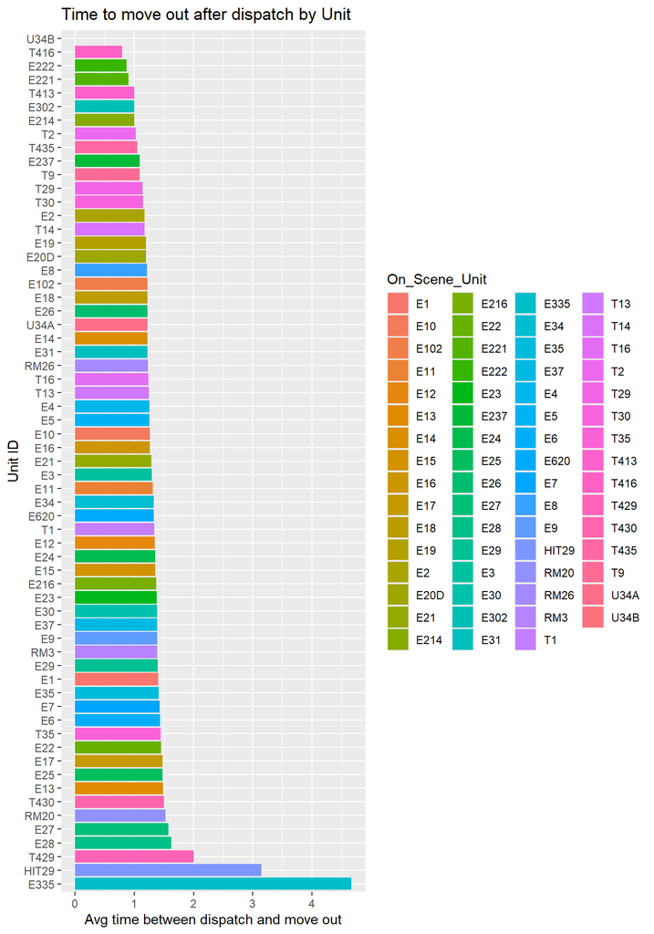

```r
nonadata %>% group_by(On_Scene_Unit) %>% summarise(avg = mean(d_to_otw_min)) %>% ggplot(mapping = aes(x = reorder(On_Scene_Unit, -avg), y = avg, fill=On_Scene_Unit)) + geom_bar(stat = "identity") + coord_flip() + labs(y="Avg time between dispatch and move out", x="Unit ID", title="Time to move out after dispatch by Unit")
```

This looks much healthier since on average it takes no more than 5 minutes for any unit to move out in even the most extreme cases. Most of the time it is less than 2 minutes on average. Pretty impressive.

Check how much time it takes to get to destination

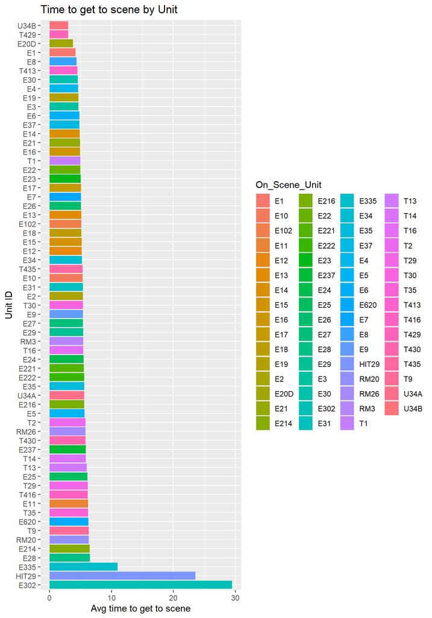

```r
nonadata %>% group_by(On_Scene_Unit) %>% summarise(avg = mean(otw_to_os_min)) %>% ggplot(mapping = aes(x = reorder(On_Scene_Unit, -avg), y = avg, fill=On_Scene_Unit)) + geom_bar(stat = "identity") + coord_flip() + labs(y="Avg time to get to scene", x="Unit ID", title="Time to get to scene by Unit")
```

There is something going on with unit E302 and HIT29, the two niche ones that we noticed before, but on average, it takes less than 10 minutes for firefighters to get to their destination.

Last but not least, average time to deal with the situation on scene.

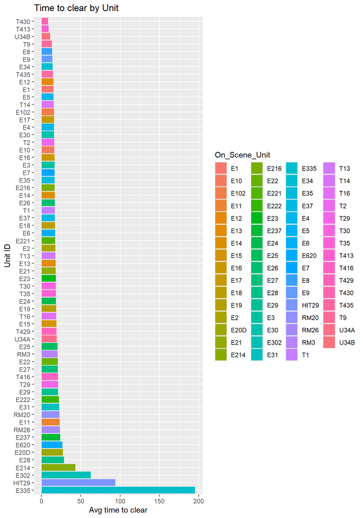

```r
nonadata %>% group_by(On_Scene_Unit) %>% summarise(avg = mean(os_to_c_min)) %>% ggplot(mapping = aes(x = reorder(On_Scene_Unit, -avg), y = avg, fill=On_Scene_Unit)) + geom_bar(stat = "identity") + coord_flip() + labs(y="Avg time to clear", x="Unit ID", title="Time to clear by Unit")
```

For the most part, it seems that, on average, most units deal with the situation within ~25 minutes after their arrival. We can also see a tendency of E335, HIT29 and E302 units being the 3 most special units also because it takes the longest for them to complete their mission. The graph adds more validity to the theory of them being the most specialized ones since the tasks they cover must be very difficult if they take so long to deal with.

Let’s check the Priority spread for further analysis later.

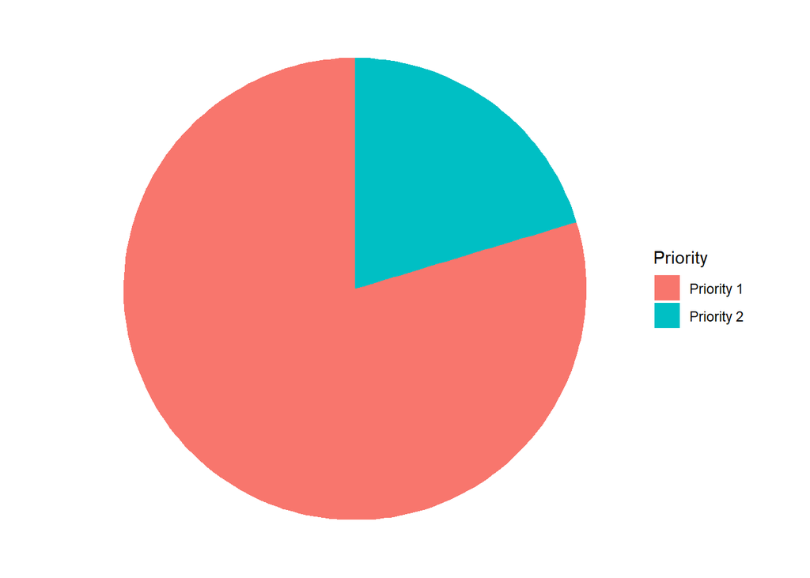

```r
nonadata %>%  group_by(Priority) %>% summarise(n = n()) %>% ggplot() + geom_bar(mapping = aes(x="", y = n,fill=Priority), stat="identity") + coord_polar("y", start=0) + theme_void()
```

It seems most cases get assigned first priority, which is the more important incidents requiring faster response.

Let’s check the spread of incident types, medical vs non-medical.

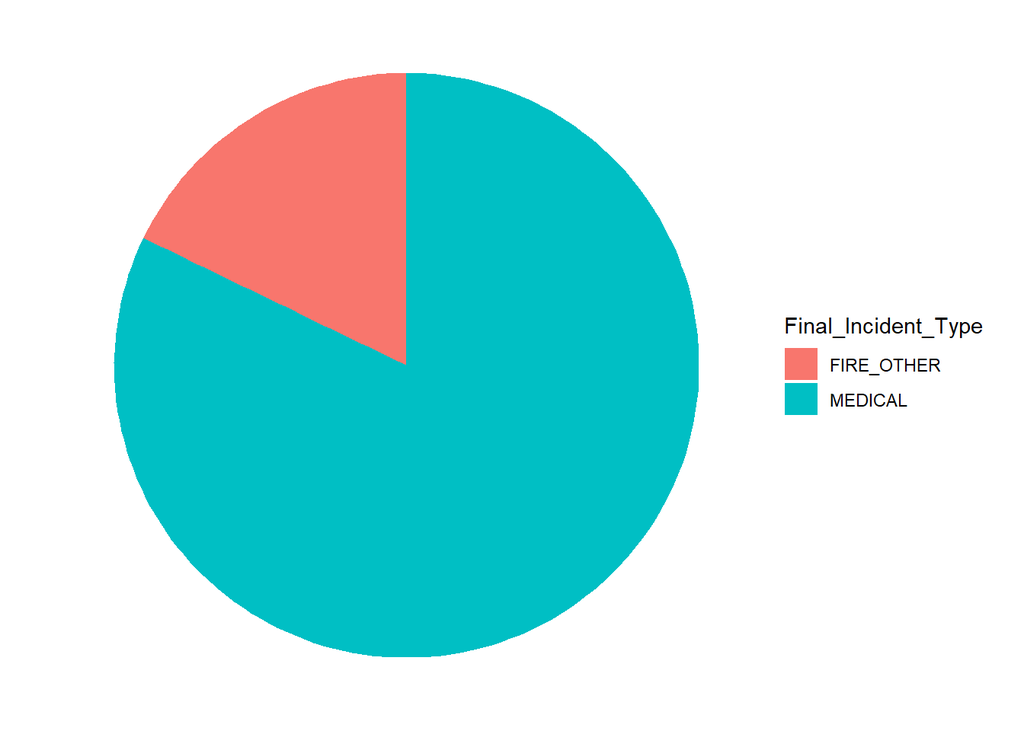

```r
nonadata %>%  group_by(Final_Incident_Type) %>% summarise(n = n()) %>% ggplot() + geom_bar(mapping = aes(x="", y = n,fill=Final_Incident_Type), stat="identity") + coord_polar("y", start=0) + theme_void()
```

It seems the majority of incidents are medical which poses a question of how related are priority and it being a medical emergency.

Check the Incident categories spread.

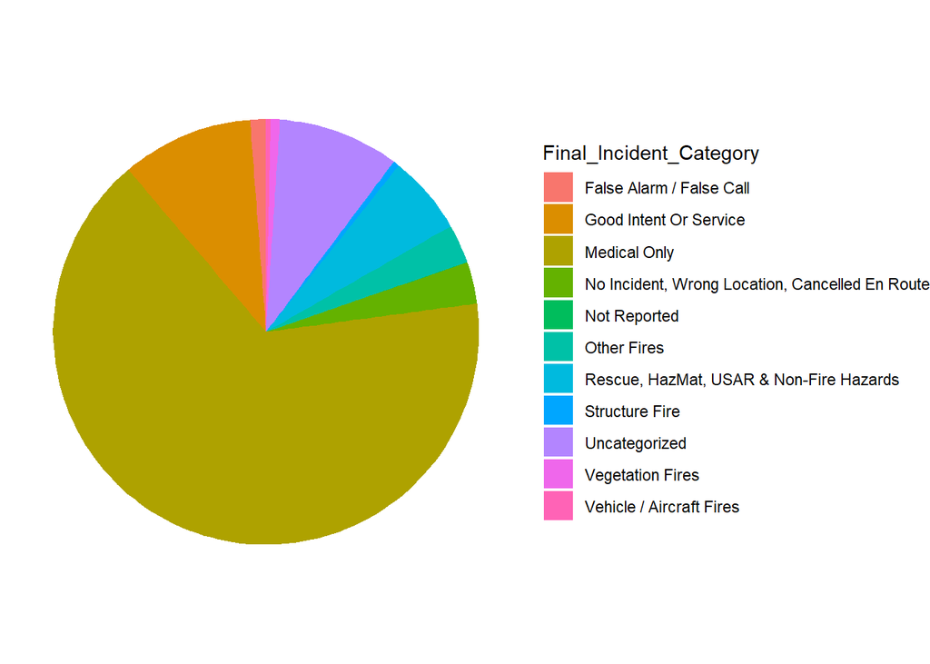

```r
nonadata %>%  group_by(Final_Incident_Category) %>% summarise(n = n()) %>% ggplot() + geom_bar(mapping = aes(x="", y = n,fill=Final_Incident_Category), stat="identity") + coord_polar("y", start=0) + theme_void()
```

From this we can see that most incidents are medical only emergencies. The 3 biggest categories after are Uncategorized, Good Intent Or Service (false alarm with good intent) and Rescue/HazMat/Usar & Non-fire Hazards. Actual Fire related incidents are fairly rare.

Finally, to take a peek at priority and category relations.

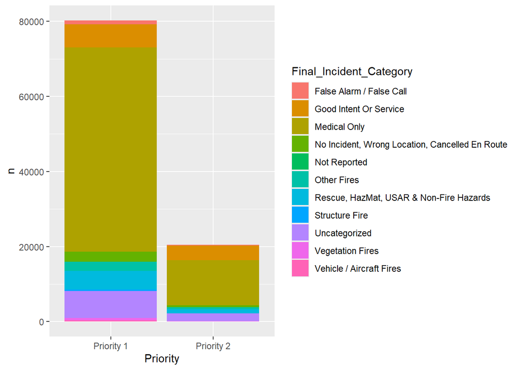

```r
nonadata %>%  group_by(Final_Incident_Category,Priority) %>% summarise(n = n()) %>% ggplot() + geom_bar(mapping = aes(x=Priority, y = n,fill=Final_Incident_Category), stat="identity")
```

From this graph we can see that, indeed, a lot of medical emergencies are first priority but it is not necessarily always the case. The curious part is that even fires are not guaranteed to be first priority at all times. We can see a tiny pink line in priority 2 bar indicating a vehicle/aircraft fires. We can see that priorities are assigned on a strictly case by case basis and the only hard rule might be structure/vegetation fires being a first priority at all times but it is unconfirmed.

That concludes my EDA.

## Data Analysis

Part 1.

Hypothesis Testing

For hypothesis testing I will investigate the following hypothesis:

H_0: mean time of arrival for Priority 1 incidents = mean time arrival for Priority 2 incidents

H_1: mean time of arrival for Priority 1 incidents < mean time arrival for Priority 2 incidents

Some logistics before the test itself. Calculating arrival time (dispatch to on the way time + on the way to on sight time)

Then splitting in two subsets for each priority type.

```r
nonadata$arrival_time <- nonadata$d_to_otw + nonadata$otw_to_os
first_priority <- subset(nonadata, Priority == "Priority 1")
second_priority <- subset(nonadata, Priority == "Priority 2")
```

Performing 2 sample mean t-test

```r
t_test_result <- t.test(first_priority$arrival_time, second_priority$arrival_time,
                        alternative = "less", # one-tailed test
                        var.equal = FALSE)

t_test_result
```

```
##
##  Welch Two Sample t-test
##
## data:  first_priority$arrival_time and second_priority$arrival_time
## t = -35.974, df = 22380, p-value < 2.2e-16
## alternative hypothesis: true difference in means is less than 0
## 95 percent confidence interval:
##      -Inf -1.50999
## sample estimates:
## mean of x mean of y
##  6.162114  7.744456
```

From the t-test performed, the mean time of arrival for Priority 1 incidents is much smaller than that of Priority 2 incidents, therefore we reject the null hypothesis.

Part 2.

Another question that comes to mind is, how do the firefighters perform through the year? Do they get tired through the year and perform worse? For that purpose I will use Linear Regression to see the trend in time of arrival

Some preparations at first, I will group the data by months and get an average time of arrival for each.

```r
nonadata$month <- format(nonadata$Date_Time_Of_Event, "%Y-%m")
averages <- (nonadata %>% group_by(month) %>% summarise(avg = mean(arrival_time)))
averages$month <- as.Date(paste0(averages$month, "-01"))
```

Now calculating the linear function and plotting it.

```r
linear_function <- lm(averages$avg ~ averages$month)
summary(linear_function)
```

```
##
## Call:
## lm(formula = averages$avg ~ averages$month)
##
## Residuals:
##      Min       1Q   Median       3Q      Max
## -0.05668 -0.03879  0.01401  0.02565  0.07434
##
## Coefficients:
##                  Estimate Std. Error t value Pr(>|t|)
## (Intercept)     7.647e+00  2.436e+00   3.139   0.0105 *
## averages$month -5.957e-05  1.248e-04  -0.477   0.6433
## ---
## Signif. codes:  0 '***' 0.001 '**' 0.01 '*' 0.05 '.' 0.1 ' ' 1
##
## Residual standard error: 0.04539 on 10 degrees of freedom
## Multiple R-squared:  0.02229,    Adjusted R-squared:  -0.07548
## F-statistic: 0.228 on 1 and 10 DF,  p-value: 0.6433
```

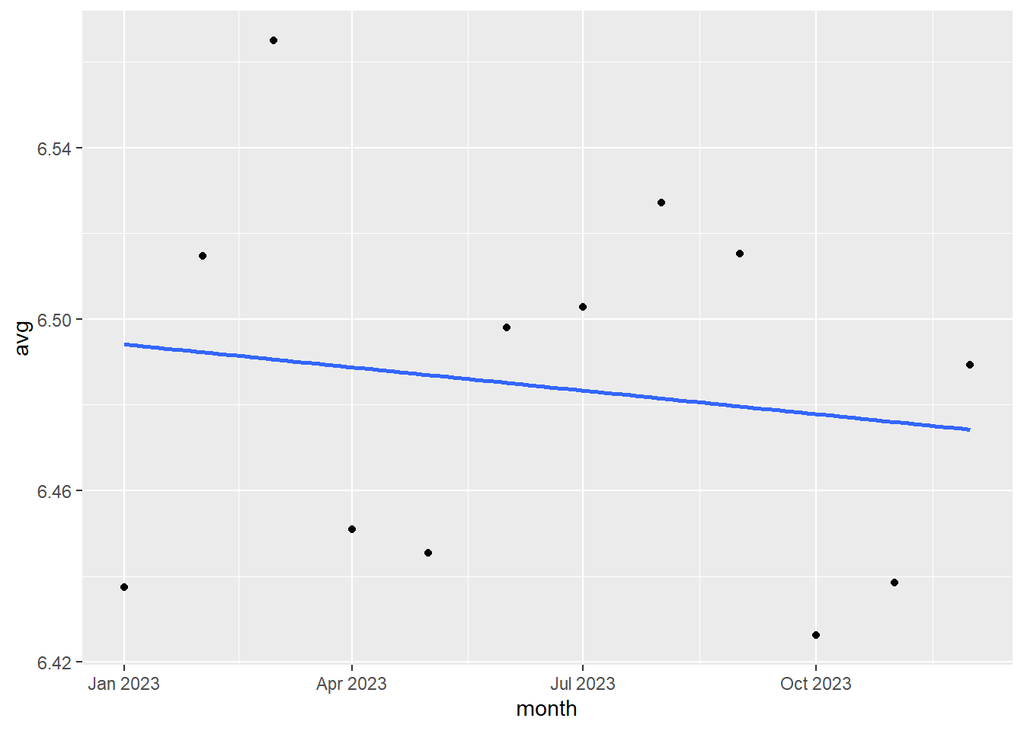

```r
ggplot(averages, aes(x = month, y=avg)) + geom_point() + geom_smooth(method = "lm", se=FALSE) +  geom_abline(slope = coef(linear_function))
```

## Conclusion

From my assessment, the Firefighters force in San Jose are performing quite well. Aside from some very strange outlier cases they are arriving on scene very fast and also stable. If anything, the trend for mean arrival time was going down through the year. It is also evident that the Priority system in place is working and the firefighters do arrive to incidents requiring faster response quicker than to those that allow some time for maneuvers. From EDA it is also evident that a lot of incidents are actually medical in nature and are not related to firefighters’ direct responsibilities.

## References

Acquired dataset from: https://data.sanjoseca.gov/ The R code is composed using in-class materials and in-class books with miscellaneous use of internet for syntax (ex: stackoverflow.com).